# Assignment

PGIS/M/DTS/20/09

6/17/2021

# Assignment 2

1. The dataset can be obtained from https://stats.idre.ucla.edu/stat/data/mmreg.csv. Name the variables

```r
dataset <- read.csv("./mmreg.csv", header = TRUE)
newheaders <- c("Control","Concept","Motivation","Read","Write","Math","Science","Sex")
colnames(dataset) <- newheaders
#head(dataset)

library(knitr)
library(kableExtra)
kable(dataset[0:10,])
```

| Control | Concept | Motivation | Read | Write | Math | Science | Sex |
| --- | --- | --- | --- | --- | --- | --- | --- |
| -0.84 | -0.24 | 1.00 | 54.8 | 64.5 | 44.5 | 52.6 | 1 |
| -0.38 | -0.47 | 0.67 | 62.7 | 43.7 | 44.7 | 52.6 | 1 |
| 0.89 | 0.59 | 0.67 | 60.6 | 56.7 | 70.5 | 58.0 | 0 |
| 0.71 | 0.28 | 0.67 | 62.7 | 56.7 | 54.7 | 58.0 | 0 |
| -0.64 | 0.03 | 1.00 | 41.6 | 46.3 | 38.4 | 36.3 | 1 |
| 1.11 | 0.90 | 0.33 | 62.7 | 64.5 | 61.4 | 58.0 | 1 |
| 0.06 | 0.03 | 0.67 | 41.6 | 39.1 | 56.3 | 45.0 | 0 |
| -0.91 | -0.59 | 0.67 | 44.2 | 39.1 | 46.3 | 36.3 | 0 |
| 0.45 | 0.03 | 1.00 | 62.7 | 51.5 | 54.4 | 49.8 | 1 |
| 0.00 | 0.03 | 0.67 | 62.7 | 64.5 | 38.3 | 55.8 | 1 |

2. Obtain the summary statistics of each numerical variable and find correlation matrix for psychological and academic variables separately, and the cross correlation of the two sets using matcor function. Show visualization of these correlations using img.matcor function in CCA R package.

summary statistics.

```r
summary(dataset)
```

```
##     Control            Concept            Motivation          Read
##  Min.   :-2.23000   Min.   :-2.620000   Min.   :0.0000   Min.   :28.3
##  1st Qu.:-0.37250   1st Qu.:-0.300000   1st Qu.:0.3300   1st Qu.:44.2
##  Median : 0.21000   Median : 0.030000   Median :0.6700   Median :52.1
##  Mean   : 0.09653   Mean   : 0.004917   Mean   :0.6608   Mean   :51.9
##  3rd Qu.: 0.51000   3rd Qu.: 0.440000   3rd Qu.:1.0000   3rd Qu.:60.1
##  Max.   : 1.36000   Max.   : 1.190000   Max.   :1.0000   Max.   :76.0
##      Write            Math          Science           Sex
##  Min.   :25.50   Min.   :31.80   Min.   :26.00   Min.   :0.000
##  1st Qu.:44.30   1st Qu.:44.50   1st Qu.:44.40   1st Qu.:0.000
##  Median :54.10   Median :51.30   Median :52.60   Median :1.000
##  Mean   :52.38   Mean   :51.85   Mean   :51.76   Mean   :0.545
##  3rd Qu.:59.90   3rd Qu.:58.38   3rd Qu.:58.65   3rd Qu.:1.000
##  Max.   :67.10   Max.   :75.50   Max.   :74.20   Max.   :1.000
```

Correlation matrix for psychological and academic variables,

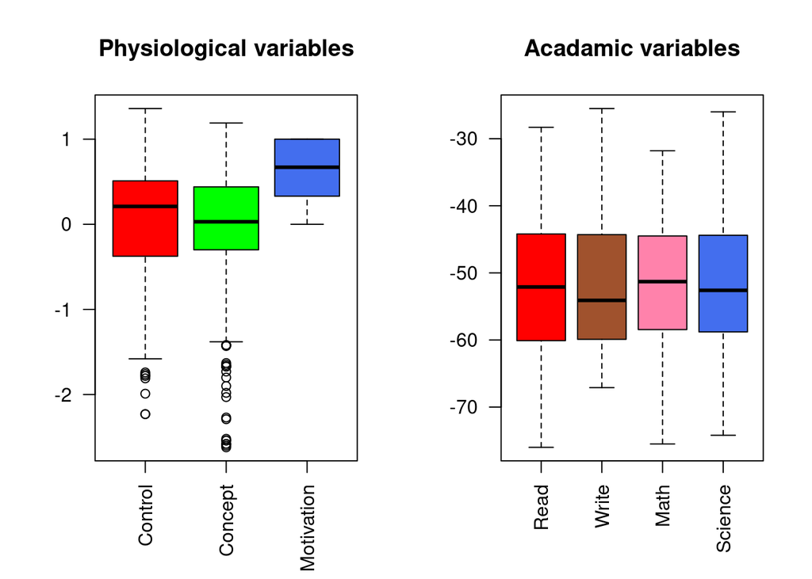

```r
#Divide the dataset as psychological and academic


psycho <- dataset[,1:3]
acadamic <--dataset[,4:7]

par(mfrow=c(1,2))
boxplot(psycho, main="Physiological variables",las=2, col=c("red","green","royalblue2"))
boxplot(acadamic, main="Acadamic variables",las=2, col =c("red","sienna","palevioletred1","royalblue2","green"))
```

Now, we find correlation matrix for psychological variables and Acadamic separately, and the two sets of variables together using matcor function.

[output not shown]

[output not shown]

```
## $Xcor
##              Control   Concept Motivation
## Control    1.0000000 0.1711878  0.2451323
## Concept    0.1711878 1.0000000  0.2885707
## Motivation 0.2451323 0.2885707  1.0000000
##
## $Ycor
##              Read     Write      Math   Science
## Read    1.0000000 0.6285909 0.6792757 0.6906929
## Write   0.6285909 1.0000000 0.6326664 0.5691498
## Math    0.6792757 0.6326664 1.0000000 0.6495261
## Science 0.6906929 0.5691498 0.6495261 1.0000000
##
## $XYcor
##               Control     Concept Motivation        Read       Write       Math
## Control     1.0000000  0.17118778  0.2451323 -0.37356505 -0.35887684 -0.3372690
## Concept     0.1711878  1.00000000  0.2885707 -0.06065584 -0.01944856 -0.0535977
## Motivation  0.2451323  0.28857075  1.0000000 -0.21060992 -0.25424818 -0.1950135
## Read       -0.3735650 -0.06065584 -0.2106099  1.00000000  0.62859089  0.6792757
## Write      -0.3588768 -0.01944856 -0.2542482  0.62859089  1.00000000  0.6326664
## Math       -0.3372690 -0.05359770 -0.1950135  0.67927568  0.63266640  1.0000000
## Science    -0.3246269 -0.06982633 -0.1156695  0.69069291  0.56914983  0.6495261
##                Science
## Control    -0.32462694
## Concept    -0.06982633
## Motivation -0.11566948
## Read        0.69069291
## Write       0.56914983
## Math        0.64952612
## Science     1.00000000
```

In X variables (psychological) set, the variable Control is have Negligible Postive correlation with variable Concept and Motivation. Also, variable Concept and Motivation have Negligible Positive correlation

In Y variables (Acadamic) set, the variable Read is have Moderate positive correlation with variable Write, Math, Science. The variable Write is have Moderate positive correlation with the variable Math and Science. Also, the variable Math have a Moderate positive correlation with Science.

When considering the correlation between X set of variables with Y set of variables, Control with Read, Write, Math, Science have Low negative correlation.

Now, we visualize the correlation.

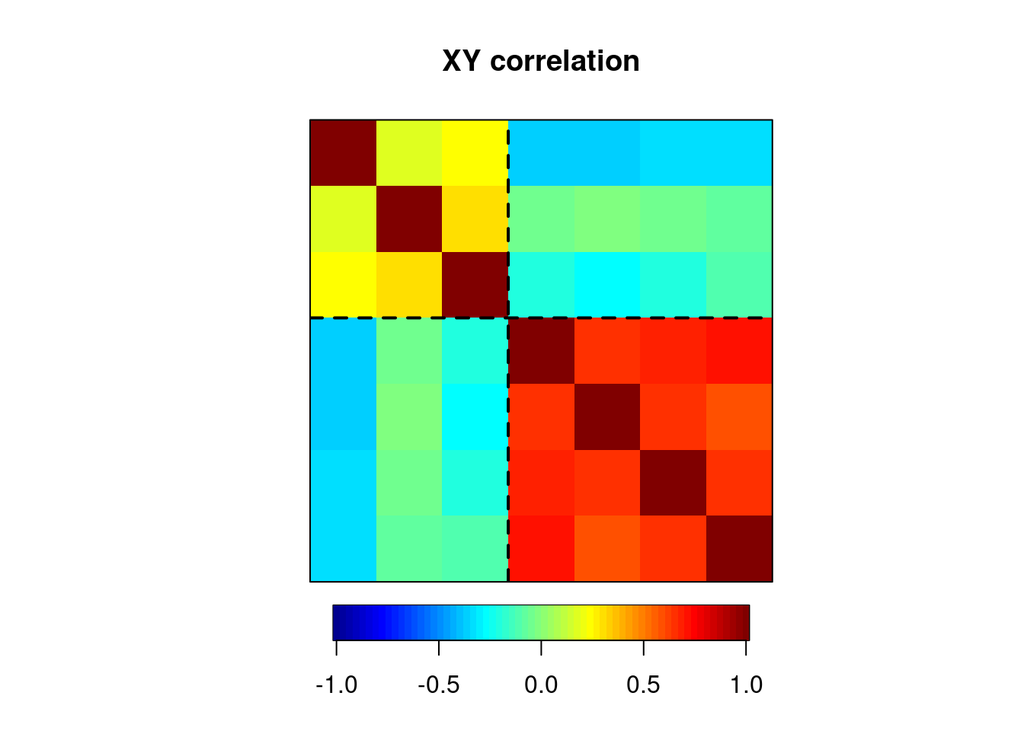

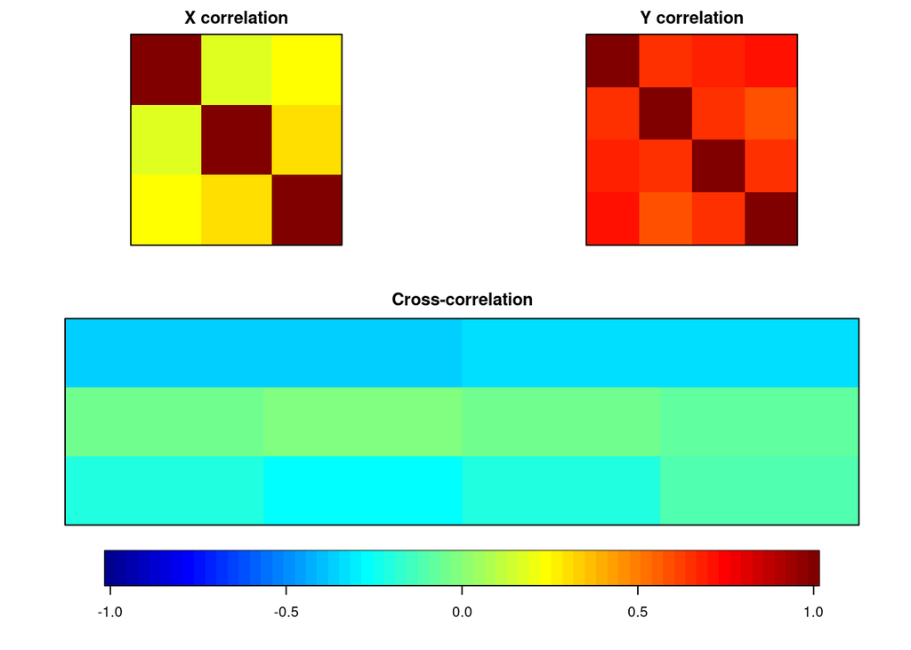

Correlation among the two sets are somewhat low. Before applying the canonical correlation analysis, we check the multivariate normality of data.

```r
library(MVN)
# Apply Madia test for multivariate normality
mvn(data = dataset,subset = NULL,mvnTest = "ma")
```

```
## $multivariateNormality
##              Test         Statistic              p value Result
## 1 Mardia Skewness  314.412564213657 2.38584735128298e-19     NO
## 2 Mardia Kurtosis -1.35106023049443    0.176676139618345    YES
## 3             MVN              <NA>                 <NA>     NO
##
## $univariateNormality
##           Test   Variable Statistic   p value Normality
## 1 Shapiro-Wilk  Control      0.9710  <0.001      NO
## 2 Shapiro-Wilk  Concept      0.9410  <0.001      NO
## 3 Shapiro-Wilk Motivation    0.8238  <0.001      NO
## 4 Shapiro-Wilk    Read       0.9816  <0.001      NO
## 5 Shapiro-Wilk   Write       0.9533  <0.001      NO
## 6 Shapiro-Wilk    Math       0.9835  <0.001      NO
## 7 Shapiro-Wilk  Science      0.9830  <0.001      NO
## 8 Shapiro-Wilk    Sex        0.6336  <0.001      NO
##
## $Descriptives
##              n         Mean    Std.Dev Median   Min   Max    25th   75th
## Control    600  0.096533333  0.6702799   0.21 -2.23  1.36 -0.3725  0.510
## Concept    600  0.004916667  0.7055125   0.03 -2.62  1.19 -0.3000  0.440
## Motivation 600  0.660833333  0.3427294   0.67  0.00  1.00  0.3300  1.000
## Read       600 51.901833333 10.1029829  52.10 28.30 76.00 44.2000 60.100
## Write      600 52.384833333  9.7264550  54.10 25.50 67.10 44.3000 59.900
## Math       600 51.849000000  9.4147364  51.30 31.80 75.50 44.5000 58.375
## Science    600 51.763333333  9.7061787  52.60 26.00 74.20 44.4000 58.650
## Sex        600  0.545000000  0.4983864   1.00  0.00  1.00  0.0000  1.000
##                  Skew   Kurtosis
## Control    -0.6080030  0.3051534
## Concept    -0.8906122  1.5222415
## Motivation -0.5878532 -0.8945072
## Read        0.1261886 -0.7693525
## Write      -0.4701256 -0.7142250
## Math        0.2631610 -0.6530141
## Science    -0.1596012 -0.7016073
## Sex        -0.1802818 -1.9707748
```

```r
# Apply Henze-Zirkler test for multivariate normality
mvn(data = dataset ,subset = NULL,mvnTest = "hz")
```

```
## $multivariateNormality
##            Test       HZ p value MVN
## 1 Henze-Zirkler 1.536898       0  NO
##
## $univariateNormality
##           Test   Variable Statistic   p value Normality
## 1 Shapiro-Wilk  Control      0.9710  <0.001      NO
## 2 Shapiro-Wilk  Concept      0.9410  <0.001      NO
## 3 Shapiro-Wilk Motivation    0.8238  <0.001      NO
## 4 Shapiro-Wilk    Read       0.9816  <0.001      NO
## 5 Shapiro-Wilk   Write       0.9533  <0.001      NO
## 6 Shapiro-Wilk    Math       0.9835  <0.001      NO
## 7 Shapiro-Wilk  Science      0.9830  <0.001      NO
## 8 Shapiro-Wilk    Sex        0.6336  <0.001      NO
##
## $Descriptives
##              n         Mean    Std.Dev Median   Min   Max    25th   75th
## Control    600  0.096533333  0.6702799   0.21 -2.23  1.36 -0.3725  0.510
## Concept    600  0.004916667  0.7055125   0.03 -2.62  1.19 -0.3000  0.440
## Motivation 600  0.660833333  0.3427294   0.67  0.00  1.00  0.3300  1.000
## Read       600 51.901833333 10.1029829  52.10 28.30 76.00 44.2000 60.100
## Write      600 52.384833333  9.7264550  54.10 25.50 67.10 44.3000 59.900
## Math       600 51.849000000  9.4147364  51.30 31.80 75.50 44.5000 58.375
## Science    600 51.763333333  9.7061787  52.60 26.00 74.20 44.4000 58.650
## Sex        600  0.545000000  0.4983864   1.00  0.00  1.00  0.0000  1.000
##                  Skew   Kurtosis
## Control    -0.6080030  0.3051534
## Concept    -0.8906122  1.5222415
## Motivation -0.5878532 -0.8945072
## Read        0.1261886 -0.7693525
## Write      -0.4701256 -0.7142250
## Math        0.2631610 -0.6530141
## Science    -0.1596012 -0.7016073
## Sex        -0.1802818 -1.9707748
```

```r
# Apply Royston test for multivariate normality
mvn(data = dataset,subset = NULL,mvnTest = "royston")
```

```
## $multivariateNormality
##      Test        H      p value MVN
## 1 Royston 466.0259 1.178161e-95  NO
##
## $univariateNormality
##           Test   Variable Statistic   p value Normality
## 1 Shapiro-Wilk  Control      0.9710  <0.001      NO
## 2 Shapiro-Wilk  Concept      0.9410  <0.001      NO
## 3 Shapiro-Wilk Motivation    0.8238  <0.001      NO
## 4 Shapiro-Wilk    Read       0.9816  <0.001      NO
## 5 Shapiro-Wilk   Write       0.9533  <0.001      NO
## 6 Shapiro-Wilk    Math       0.9835  <0.001      NO
## 7 Shapiro-Wilk  Science      0.9830  <0.001      NO
## 8 Shapiro-Wilk    Sex        0.6336  <0.001      NO
##
## $Descriptives
##              n         Mean    Std.Dev Median   Min   Max    25th   75th
## Control    600  0.096533333  0.6702799   0.21 -2.23  1.36 -0.3725  0.510
## Concept    600  0.004916667  0.7055125   0.03 -2.62  1.19 -0.3000  0.440
## Motivation 600  0.660833333  0.3427294   0.67  0.00  1.00  0.3300  1.000
## Read       600 51.901833333 10.1029829  52.10 28.30 76.00 44.2000 60.100
## Write      600 52.384833333  9.7264550  54.10 25.50 67.10 44.3000 59.900
## Math       600 51.849000000  9.4147364  51.30 31.80 75.50 44.5000 58.375
## Science    600 51.763333333  9.7061787  52.60 26.00 74.20 44.4000 58.650
## Sex        600  0.545000000  0.4983864   1.00  0.00  1.00  0.0000  1.000
##                  Skew   Kurtosis
## Control    -0.6080030  0.3051534
## Concept    -0.8906122  1.5222415
## Motivation -0.5878532 -0.8945072
## Read        0.1261886 -0.7693525
## Write      -0.4701256 -0.7142250
## Math        0.2631610 -0.6530141
## Science    -0.1596012 -0.7016073
## Sex        -0.1802818 -1.9707748
```

above three tests deny the assumption of multivariate normality. Mardia Kurtosis test follows multivariate normality. When considering the univariate normality, Shapiro-Wilk test confirms that all variables are non-normal.

Now, we the check outliers by using the “adjusted robust Mahalanobis distance”.

```r
result <- mvn(data = dataset[1:7] ,multivariateOutlierMethod = "adj",showOutliers = TRUE, showNewData = TRUE)
```

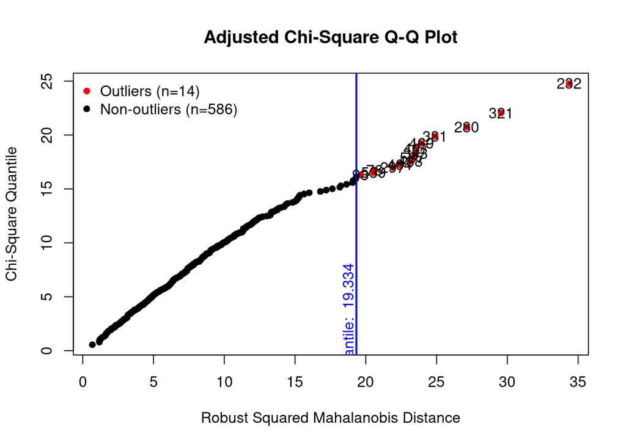

When we remove all outliers, all the test seems to fail. let’s remove few extreame ourlier,

```r
dataset_new <- dataset[-c(321),]
```

now check the multivariate normality of data. Still univariate tests fails.

```r
library(MVN)
# Apply Madia test for multivariate normality
mvn(data = dataset_new,subset = NULL,mvnTest = "ma")
```

```
## $multivariateNormality
##              Test         Statistic              p value Result
## 1 Mardia Skewness  304.961637267967 4.52649308115825e-18     NO
## 2 Mardia Kurtosis -1.47698670952167    0.139679199917049    YES
## 3             MVN              <NA>                 <NA>     NO
##
## $univariateNormality
##           Test   Variable Statistic   p value Normality
## 1 Shapiro-Wilk  Control      0.9711  <0.001      NO
## 2 Shapiro-Wilk  Concept      0.9438  <0.001      NO
## 3 Shapiro-Wilk Motivation    0.8234  <0.001      NO
## 4 Shapiro-Wilk    Read       0.9818  <0.001      NO
## 5 Shapiro-Wilk   Write       0.9535  <0.001      NO
## 6 Shapiro-Wilk    Math       0.9834  <0.001      NO
## 7 Shapiro-Wilk  Science      0.9828  <0.001      NO
## 8 Shapiro-Wilk    Sex        0.6337  <0.001      NO
##
## $Descriptives
##              n         Mean    Std.Dev Median   Min   Max   25th  75th
## Control    599  0.096243740  0.6708025   0.21 -2.23  1.36 -0.375  0.51
## Concept    599  0.009131886  0.6984995   0.03 -2.62  1.19 -0.300  0.44
## Motivation 599  0.661385643  0.3427485   0.67  0.00  1.00  0.330  1.00
## Read       599 51.923539232 10.0974150  52.10 28.30 76.00 44.200 60.10
## Write      599 52.418864775  9.6987670  54.10 25.50 67.10 44.300 59.90
## Math       599 51.876627713  9.3982309  51.30 31.80 75.50 44.500 58.45
## Science    599 51.771953255  9.7119921  52.60 26.00 74.20 44.400 58.80
## Sex        599  0.544240401  0.4984552   1.00  0.00  1.00  0.000  1.00
##                  Skew   Kurtosis
## Control    -0.6063316  0.2993100
## Concept    -0.8584614  1.4499369
## Motivation -0.5920610 -0.8891108
## Read        0.1237345 -0.7663771
## Write      -0.4699636 -0.7102081
## Math        0.2653022 -0.6517588
## Science    -0.1619881 -0.7028406
## Sex        -0.1772137 -1.9718789
```

Let’s try to replace the outliers with median values,

```r
outlier <- function(x) {
 x[x < quantile(x,0.25) - 1.5 * IQR(x) | x > quantile(x,0.75) + 1.5 * IQR(x)] <- median(x)
 x
}

dataset_new <- data.frame(lapply(dataset_new[,1:7], outlier))
```

```r
library(MVN)
# Apply Madia test for multivariate normality
mvn(data = dataset_new,subset = NULL,mvnTest = "ma")
```

```
## $multivariateNormality
##              Test         Statistic              p value Result
## 1 Mardia Skewness  179.332865157697 7.08267720178359e-09     NO
## 2 Mardia Kurtosis -1.91192338645534   0.0558860215451746    YES
## 3             MVN              <NA>                 <NA>     NO
##
## $univariateNormality
##           Test   Variable Statistic   p value Normality
## 1 Shapiro-Wilk  Control      0.9777  <0.001      NO
## 2 Shapiro-Wilk  Concept      0.9689  <0.001      NO
## 3 Shapiro-Wilk Motivation    0.8234  <0.001      NO
## 4 Shapiro-Wilk    Read       0.9818  <0.001      NO
## 5 Shapiro-Wilk   Write       0.9535  <0.001      NO
## 6 Shapiro-Wilk    Math       0.9834  <0.001      NO
## 7 Shapiro-Wilk  Science      0.9828  <0.001      NO
##
## $Descriptives
##              n        Mean    Std.Dev Median   Min   Max   25th  75th
## Control    599  0.12462437  0.6282636   0.21 -1.58  1.36 -0.255  0.51
## Concept    599  0.08559265  0.5705961   0.03 -1.38  1.19 -0.260  0.44
## Motivation 599  0.66138564  0.3427485   0.67  0.00  1.00  0.330  1.00
## Read       599 51.92353923 10.0974150  52.10 28.30 76.00 44.200 60.10
## Write      599 52.41886477  9.6987670  54.10 25.50 67.10 44.300 59.90
## Math       599 51.87662771  9.3982309  51.30 31.80 75.50 44.500 58.45
## Science    599 51.77195326  9.7119921  52.60 26.00 74.20 44.400 58.80
##                  Skew   Kurtosis
## Control    -0.4224085 -0.1347437
## Concept    -0.1641740 -0.1589092
## Motivation -0.5920610 -0.8891108
## Read        0.1237345 -0.7663771
## Write      -0.4699636 -0.7102081
## Math        0.2653022 -0.6517588
## Science    -0.1619881 -0.7028406
```

```r
# Apply Henze-Zirkler test for multivariate normality
mvn(data = dataset_new ,subset = NULL,mvnTest = "hz")
```

```
## $multivariateNormality
##            Test       HZ p value MVN
## 1 Henze-Zirkler 1.281936       0  NO
##
## $univariateNormality
##           Test   Variable Statistic   p value Normality
## 1 Shapiro-Wilk  Control      0.9777  <0.001      NO
## 2 Shapiro-Wilk  Concept      0.9689  <0.001      NO
## 3 Shapiro-Wilk Motivation    0.8234  <0.001      NO
## 4 Shapiro-Wilk    Read       0.9818  <0.001      NO
## 5 Shapiro-Wilk   Write       0.9535  <0.001      NO
## 6 Shapiro-Wilk    Math       0.9834  <0.001      NO
## 7 Shapiro-Wilk  Science      0.9828  <0.001      NO
##
## $Descriptives
##              n        Mean    Std.Dev Median   Min   Max   25th  75th
## Control    599  0.12462437  0.6282636   0.21 -1.58  1.36 -0.255  0.51
## Concept    599  0.08559265  0.5705961   0.03 -1.38  1.19 -0.260  0.44
## Motivation 599  0.66138564  0.3427485   0.67  0.00  1.00  0.330  1.00
## Read       599 51.92353923 10.0974150  52.10 28.30 76.00 44.200 60.10
## Write      599 52.41886477  9.6987670  54.10 25.50 67.10 44.300 59.90
## Math       599 51.87662771  9.3982309  51.30 31.80 75.50 44.500 58.45
## Science    599 51.77195326  9.7119921  52.60 26.00 74.20 44.400 58.80
##                  Skew   Kurtosis
## Control    -0.4224085 -0.1347437
## Concept    -0.1641740 -0.1589092
## Motivation -0.5920610 -0.8891108
## Read        0.1237345 -0.7663771
## Write      -0.4699636 -0.7102081
## Math        0.2653022 -0.6517588
## Science    -0.1619881 -0.7028406
```

```r
# Apply Royston test for multivariate normality
mvn(data = dataset_new,subset = NULL,mvnTest = "royston")
```

```
## $multivariateNormality
##      Test        H      p value MVN
## 1 Royston 292.3307 2.280094e-59  NO
##
## $univariateNormality
##           Test   Variable Statistic   p value Normality
## 1 Shapiro-Wilk  Control      0.9777  <0.001      NO
## 2 Shapiro-Wilk  Concept      0.9689  <0.001      NO
## 3 Shapiro-Wilk Motivation    0.8234  <0.001      NO
## 4 Shapiro-Wilk    Read       0.9818  <0.001      NO
## 5 Shapiro-Wilk   Write       0.9535  <0.001      NO
## 6 Shapiro-Wilk    Math       0.9834  <0.001      NO
## 7 Shapiro-Wilk  Science      0.9828  <0.001      NO
##
## $Descriptives
##              n        Mean    Std.Dev Median   Min   Max   25th  75th
## Control    599  0.12462437  0.6282636   0.21 -1.58  1.36 -0.255  0.51
## Concept    599  0.08559265  0.5705961   0.03 -1.38  1.19 -0.260  0.44
## Motivation 599  0.66138564  0.3427485   0.67  0.00  1.00  0.330  1.00
## Read       599 51.92353923 10.0974150  52.10 28.30 76.00 44.200 60.10
## Write      599 52.41886477  9.6987670  54.10 25.50 67.10 44.300 59.90
## Math       599 51.87662771  9.3982309  51.30 31.80 75.50 44.500 58.45
## Science    599 51.77195326  9.7119921  52.60 26.00 74.20 44.400 58.80
##                  Skew   Kurtosis
## Control    -0.4224085 -0.1347437
## Concept    -0.1641740 -0.1589092
## Motivation -0.5920610 -0.8891108
## Read        0.1237345 -0.7663771
## Write      -0.4699636 -0.7102081
## Math        0.2653022 -0.6517588
## Science    -0.1619881 -0.7028406
```

Dataset still follows only Mardia Kurtosis test multivariate normality.

Let’s visualize some of the variables.. After and before replacing with median values

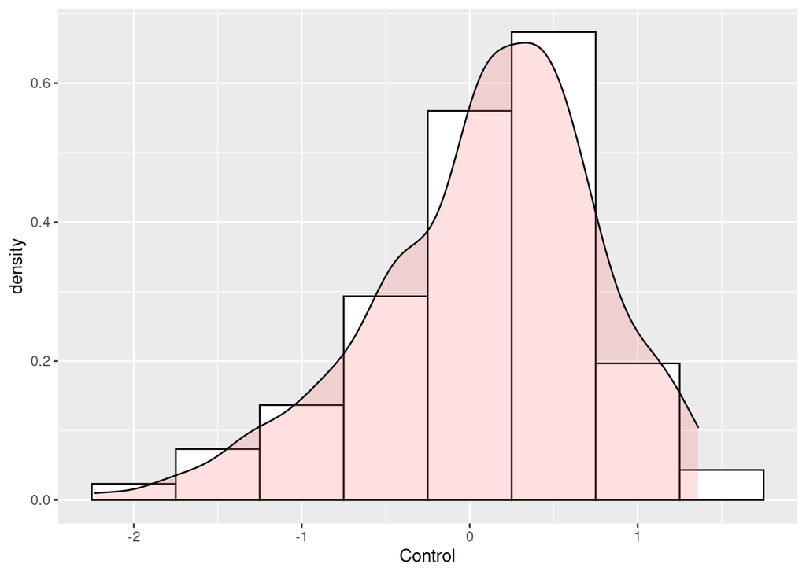

```r
#before

library(ggplot2)
ggplot(dataset, aes(x=Control)) +
    geom_histogram(aes(y=..density..),      # Histogram with density instead of count on y-axis
                   binwidth=.5,
                   colour="black", fill="white") +
    geom_density(alpha=.2, fill="#FF6666")  # Overlay with transparent density plot
```

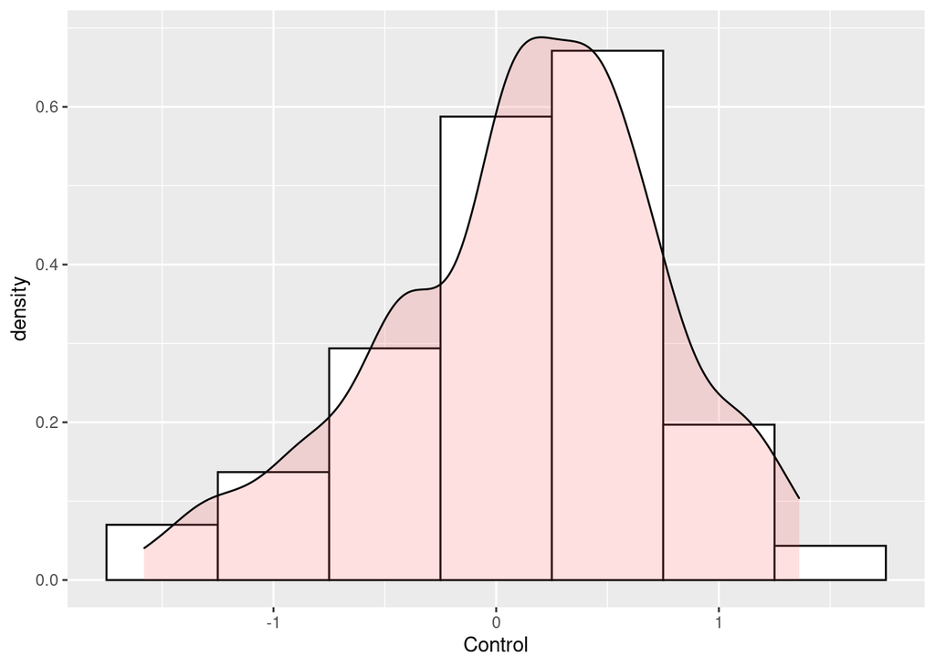

```r
#After

# Histogram overlaid with kernel density curve
ggplot(dataset_new, aes(x=Control)) +
    geom_histogram(aes(y=..density..),      # Histogram with density instead of count on y-axis
                   binwidth=.5,
                   colour="black", fill="white") +
    geom_density(alpha=.2, fill="#FF6666")  # Overlay with transparent density plot
```

Now we are going to use a datase where, extrame outlier removed, other outliers replaced with median dataset

```r
newphy <- dataset_new
kable(newphy) %>% kable_styling() %>% scroll_box(height = "200px")
```

| Control | Concept | Motivation | Read | Write | Math | Science |
| --- | --- | --- | --- | --- | --- | --- |
| -0.84 | -0.24 | 1.00 | 54.8 | 64.5 | 44.5 | 52.6 |
| -0.38 | -0.47 | 0.67 | 62.7 | 43.7 | 44.7 | 52.6 |
| 0.89 | 0.59 | 0.67 | 60.6 | 56.7 | 70.5 | 58.0 |
| 0.71 | 0.28 | 0.67 | 62.7 | 56.7 | 54.7 | 58.0 |
| -0.64 | 0.03 | 1.00 | 41.6 | 46.3 | 38.4 | 36.3 |
| 1.11 | 0.90 | 0.33 | 62.7 | 64.5 | 61.4 | 58.0 |
| 0.06 | 0.03 | 0.67 | 41.6 | 39.1 | 56.3 | 45.0 |
| -0.91 | -0.59 | 0.67 | 44.2 | 39.1 | 46.3 | 36.3 |
| 0.45 | 0.03 | 1.00 | 62.7 | 51.5 | 54.4 | 49.8 |
| 0.00 | 0.03 | 0.67 | 62.7 | 64.5 | 38.3 | 55.8 |
| 0.24 | -0.43 | 0.33 | 70.7 | 43.7 | 58.8 | 66.1 |
| -1.09 | -0.26 | 0.33 | 44.2 | 41.1 | 45.1 | 47.1 |
| 0.46 | 0.03 | 0.67 | 57.4 | 59.3 | 53.9 | 49.8 |
| 0.68 | 0.06 | 0.67 | 49.5 | 51.5 | 41.2 | 41.7 |
| -0.14 | -1.05 | 1.00 | 70.7 | 65.1 | 66.4 | 63.4 |
| 0.10 | -0.16 | 0.33 | 49.5 | 59.3 | 51.0 | 47.1 |
| 0.45 | 0.65 | 1.00 | 57.4 | 56.7 | 46.9 | 52.6 |
| -1.56 | 0.03 | 0.33 | 62.7 | 54.1 | 53.0 | 55.3 |
| -1.02 | 0.03 | 0.67 | 45.3 | 43.0 | 52.3 | 60.7 |
| 0.94 | 0.03 | 1.00 | 68.0 | 56.7 | 59.6 | 58.0 |
| -0.40 | 0.03 | 1.00 | 44.2 | 54.1 | 59.3 | 58.0 |
| -0.19 | 0.03 | 1.00 | 44.7 | 47.6 | 50.3 | 39.0 |
| 0.26 | 0.03 | 0.33 | 48.4 | 48.9 | 52.2 | 43.9 |
| 0.21 | 0.94 | 0.00 | 38.9 | 48.9 | 41.8 | 58.5 |
| 0.70 | 0.87 | 1.00 | 46.9 | 54.1 | 46.4 | 49.8 |
| 1.36 | 0.94 | 1.00 | 57.4 | 64.5 | 49.9 | 55.3 |
| -0.84 | -0.57 | 0.33 | 33.6 | 33.3 | 41.0 | 36.3 |
| -0.68 | 0.03 | 0.33 | 38.9 | 38.5 | 41.2 | 39.0 |
| -0.17 | 0.31 | 1.00 | 65.4 | 67.1 | 75.5 | 71.5 |
| 0.06 | 0.28 | 1.00 | 60.1 | 59.3 | 56.2 | 60.7 |

[output cut: 569 more lines]

Now, test the multivariate normality for the new data set.

```r
# Apply Madia test for multivariate normality
mvn(data = newphy,subset = NULL,mvnTest = "ma")
```

```
## $multivariateNormality
##              Test         Statistic              p value Result
## 1 Mardia Skewness  179.332865157697 7.08267720178359e-09     NO
## 2 Mardia Kurtosis -1.91192338645534   0.0558860215451746    YES
## 3             MVN              <NA>                 <NA>     NO
##
## $univariateNormality
##           Test   Variable Statistic   p value Normality
## 1 Shapiro-Wilk  Control      0.9777  <0.001      NO
## 2 Shapiro-Wilk  Concept      0.9689  <0.001      NO
## 3 Shapiro-Wilk Motivation    0.8234  <0.001      NO
## 4 Shapiro-Wilk    Read       0.9818  <0.001      NO
## 5 Shapiro-Wilk   Write       0.9535  <0.001      NO
## 6 Shapiro-Wilk    Math       0.9834  <0.001      NO
## 7 Shapiro-Wilk  Science      0.9828  <0.001      NO
##
## $Descriptives
##              n        Mean    Std.Dev Median   Min   Max   25th  75th
## Control    599  0.12462437  0.6282636   0.21 -1.58  1.36 -0.255  0.51
## Concept    599  0.08559265  0.5705961   0.03 -1.38  1.19 -0.260  0.44
## Motivation 599  0.66138564  0.3427485   0.67  0.00  1.00  0.330  1.00
## Read       599 51.92353923 10.0974150  52.10 28.30 76.00 44.200 60.10
## Write      599 52.41886477  9.6987670  54.10 25.50 67.10 44.300 59.90
## Math       599 51.87662771  9.3982309  51.30 31.80 75.50 44.500 58.45
## Science    599 51.77195326  9.7119921  52.60 26.00 74.20 44.400 58.80
##                  Skew   Kurtosis
## Control    -0.4224085 -0.1347437
## Concept    -0.1641740 -0.1589092
## Motivation -0.5920610 -0.8891108
## Read        0.1237345 -0.7663771
## Write      -0.4699636 -0.7102081
## Math        0.2653022 -0.6517588
## Science    -0.1619881 -0.7028406
```

```r
# Apply Henze-Zirkler test for multivariate normality
mvn(data = newphy,subset = NULL,mvnTest = "hz")
```

```
## $multivariateNormality
##            Test       HZ p value MVN
## 1 Henze-Zirkler 1.281936       0  NO
##
## $univariateNormality
##           Test   Variable Statistic   p value Normality
## 1 Shapiro-Wilk  Control      0.9777  <0.001      NO
## 2 Shapiro-Wilk  Concept      0.9689  <0.001      NO
## 3 Shapiro-Wilk Motivation    0.8234  <0.001      NO
## 4 Shapiro-Wilk    Read       0.9818  <0.001      NO
## 5 Shapiro-Wilk   Write       0.9535  <0.001      NO
## 6 Shapiro-Wilk    Math       0.9834  <0.001      NO
## 7 Shapiro-Wilk  Science      0.9828  <0.001      NO
##
## $Descriptives
##              n        Mean    Std.Dev Median   Min   Max   25th  75th
## Control    599  0.12462437  0.6282636   0.21 -1.58  1.36 -0.255  0.51
## Concept    599  0.08559265  0.5705961   0.03 -1.38  1.19 -0.260  0.44
## Motivation 599  0.66138564  0.3427485   0.67  0.00  1.00  0.330  1.00
## Read       599 51.92353923 10.0974150  52.10 28.30 76.00 44.200 60.10
## Write      599 52.41886477  9.6987670  54.10 25.50 67.10 44.300 59.90
## Math       599 51.87662771  9.3982309  51.30 31.80 75.50 44.500 58.45
## Science    599 51.77195326  9.7119921  52.60 26.00 74.20 44.400 58.80
##                  Skew   Kurtosis
## Control    -0.4224085 -0.1347437
## Concept    -0.1641740 -0.1589092
## Motivation -0.5920610 -0.8891108
## Read        0.1237345 -0.7663771
## Write      -0.4699636 -0.7102081
## Math        0.2653022 -0.6517588
## Science    -0.1619881 -0.7028406
```

```r
# Apply Royston test for multivariate normality
mvn(data = newphy,subset = NULL,mvnTest = "royston")
```

```
## $multivariateNormality
##      Test        H      p value MVN
## 1 Royston 292.3307 2.280094e-59  NO
##
## $univariateNormality
##           Test   Variable Statistic   p value Normality
## 1 Shapiro-Wilk  Control      0.9777  <0.001      NO
## 2 Shapiro-Wilk  Concept      0.9689  <0.001      NO
## 3 Shapiro-Wilk Motivation    0.8234  <0.001      NO
## 4 Shapiro-Wilk    Read       0.9818  <0.001      NO
## 5 Shapiro-Wilk   Write       0.9535  <0.001      NO
## 6 Shapiro-Wilk    Math       0.9834  <0.001      NO
## 7 Shapiro-Wilk  Science      0.9828  <0.001      NO
##
## $Descriptives
##              n        Mean    Std.Dev Median   Min   Max   25th  75th
## Control    599  0.12462437  0.6282636   0.21 -1.58  1.36 -0.255  0.51
## Concept    599  0.08559265  0.5705961   0.03 -1.38  1.19 -0.260  0.44
## Motivation 599  0.66138564  0.3427485   0.67  0.00  1.00  0.330  1.00
## Read       599 51.92353923 10.0974150  52.10 28.30 76.00 44.200 60.10
## Write      599 52.41886477  9.6987670  54.10 25.50 67.10 44.300 59.90
## Math       599 51.87662771  9.3982309  51.30 31.80 75.50 44.500 58.45
## Science    599 51.77195326  9.7119921  52.60 26.00 74.20 44.400 58.80
##                  Skew   Kurtosis
## Control    -0.4224085 -0.1347437
## Concept    -0.1641740 -0.1589092
## Motivation -0.5920610 -0.8891108
## Read        0.1237345 -0.7663771
## Write      -0.4699636 -0.7102081
## Math        0.2653022 -0.6517588
## Science    -0.1619881 -0.7028406
```

3. Obtain raw canonical correlations and the normalized canonical coefficients.

Now, we obtain raw canonical correlations.

```r
newy= newphy[,1:3]
newx=newphy[,4:7]
library(CCP)
# Find canonical correlations
raw_cca<-cancor(newx, newy)
raw_cca
```

```
## $cor
## [1] 0.43224929 0.15382905 0.01357331
##
## $xcoef
##                  [,1]          [,2]         [,3]          [,4]
## Read     0.0016443592 -0.0004636675 -0.006120120  0.0006978479
## Write    0.0025560193 -0.0028087048  0.002075258 -0.0039412694
## Math     0.0007932969 -0.0009342111  0.003030969  0.0057427792
## Science -0.0003416024  0.0056269234  0.001806799 -0.0020134662
##
## $ycoef
##                   [,1]        [,2]        [,3]
## Control     0.05261891  0.03714049  0.02139548
## Concept    -0.01997030  0.04312774 -0.05742104
## Motivation  0.05648548 -0.09627029 -0.05838060
##
## $xcenter
##     Read    Write     Math  Science
## 51.92354 52.41886 51.87663 51.77195
##
## $ycenter
##    Control    Concept Motivation
## 0.12462437 0.08559265 0.66138564
```

Then, we obtain the normalized canonical variates.

```r
newy= newphy[,1:3]
newx=newphy[,4:7]
library(CCP)
# Find canonical correlations
cca<-cancor(scale(newx, scale=T, center=T),scale(newy, scale=T,center=T))
cca
```

```
## $cor
## [1] 0.43224929 0.15382905 0.01357331
##
## $xcoef
##                 [,1]         [,2]        [,3]        [,4]
## Read     0.016603777 -0.004681843 -0.06179739  0.00704646
## Write    0.024790236 -0.027240973  0.02012744 -0.03822545
## Math     0.007455588 -0.008779931  0.02848574  0.05397197
## Science -0.003317640  0.054648635  0.01754762 -0.01955477
##
## $ycoef
##                   [,1]        [,2]        [,3]
## Control     0.03305855  0.02333402  0.01344200
## Concept    -0.01139498  0.02460852 -0.03276422
## Motivation  0.01936031 -0.03299649 -0.02000986
##
## $xcenter
##          Read         Write          Math       Science
##  1.216102e-16 -9.552274e-17  2.183985e-16  2.146366e-16
##
## $ycenter
##       Control       Concept    Motivation
## -1.971040e-17  1.397336e-18  1.181581e-16
```

4. Test the significance of the canonical correlations and find canonical loadings. Then, show the significance canonical variates.

```r
nrow(newphy)
```

```
## [1] 599
```

we test the significance of the canonical correlations.

```r
rho<-cca$cor
## Calculate p-values using the F-approximations of different test statistics:
p.asym(rho,599,3,4,tstat="Wilks") #*Here N=599, p=3,q=4
```

```
## Wilks' Lambda, using F-approximation (Rao's F):
##               stat      approx df1      df2   p.value
## 1 to 3:  0.7937722 11.90828974  12 1566.576 0.0000000
## 2 to 3:  0.9761567  2.39950341   6 1186.000 0.0261155
## 3 to 3:  0.9998158  0.05472783   2  594.000 0.9467476
```

```r
p.asym(rho, 599,3,4, tstat = "Hotelling")
```

```
##  Hotelling-Lawley Trace, using F-approximation:
##                  stat      approx df1  df2    p.value
## 1 to 3:  0.2541906120 12.51182679  12 1772 0.00000000
## 2 to 3:  0.0244211733  2.41226923   6 1778 0.02517312
## 3 to 3:  0.0001842688  0.05478925   2 1784 0.94668623
```

```r
p.asym(rho, 599,3,4, tstat = "Pillai")
```

```
##  Pillai-Bartlett Trace, using F-approximation:
##                  stat     approx df1  df2    p.value
## 1 to 3:  0.2106870568 11.2167507  12 1782 0.00000000
## 2 to 3:  0.0238476123  2.3878443   6 1788 0.02660039
## 3 to 3:  0.0001842348  0.0550896   2 1794 0.94640195
```

```r
p.asym(rho, 599,3,4, tstat = "Roy")
```

```
##  Roy's Largest Root, using F-approximation:
##               stat   approx df1 df2 p.value
## 1 to 1:  0.1868394 34.12076   4 594       0
##
##  F statistic for Roy's Greatest Root is an upper bound.
```

```r
## Plot the F-approximation for Wilks' Lambda, considering 3, 2, or 1 canonical correlation(s):
res1 <- p.asym(rho, 599,3,4)
```

```
## Wilks' Lambda, using F-approximation (Rao's F):
##               stat      approx df1      df2   p.value
## 1 to 3:  0.7937722 11.90828974  12 1566.576 0.0000000
## 2 to 3:  0.9761567  2.39950341   6 1186.000 0.0261155
## 3 to 3:  0.9998158  0.05472783   2  594.000 0.9467476
```

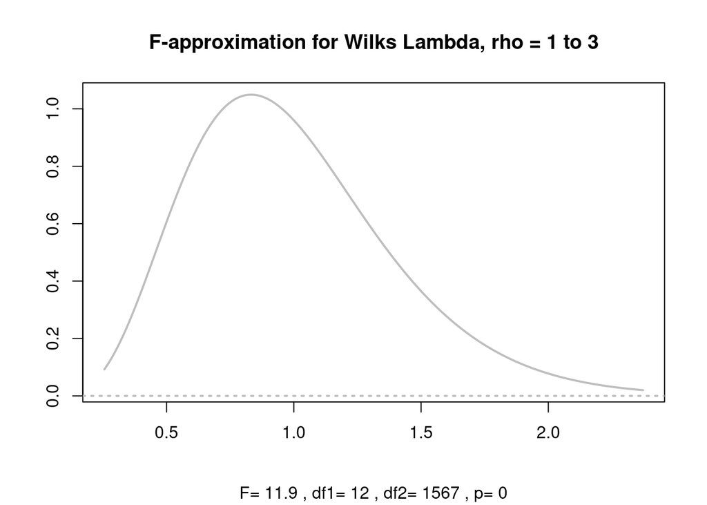

```r
plt.asym(res1,rhostart=1)
```

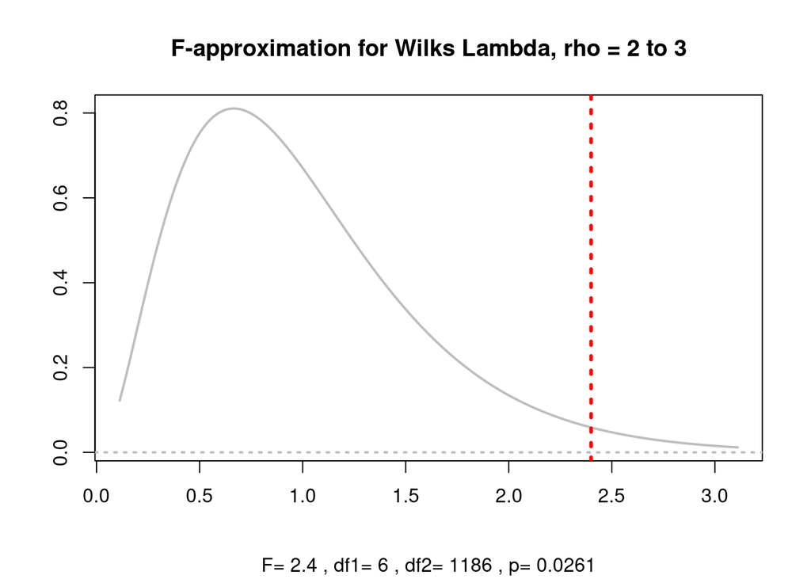

```r
plt.asym(res1,rhostart=2)
```

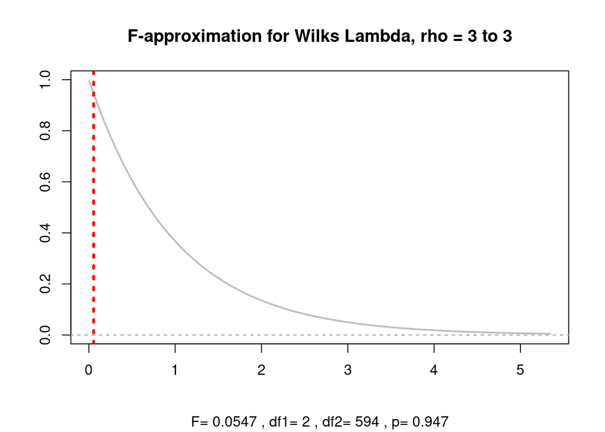

```r
plt.asym(res1,rhostart=3)
```

Look at the plot of the first canonical variates

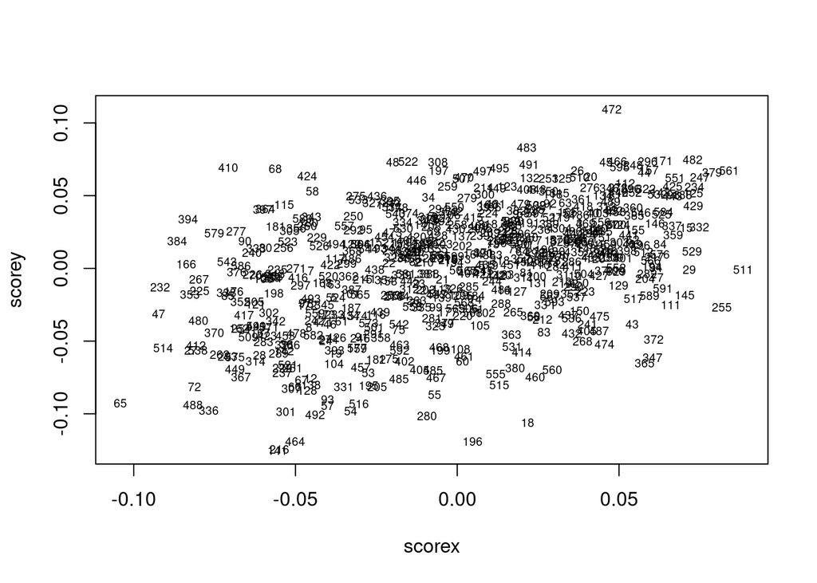

```r
xx<-scale(newx,scale=T,center=T)
yy<-scale(newy,scale=T,center=T)
scorex<-xx%*%cca$xcoef[,1]
scorey<-yy%*%cca$ycoef[,1]
plot(scorex,scorey,type="n")
text(scorex,scorey,row.names(newphy),cex=.6)
```

To obtain the canonical loadings, we can run the following codes.

```r
cancor<-cc(newx,newy)
comput(newx,newy,cancor)[3:6]
```

```
## $corr.X.xscores
##               [,1]       [,2]       [,3]
## Read    -0.8538969  0.2450492  0.4336726
## Write   -0.9296438 -0.1122383 -0.2278439
## Math    -0.7871568  0.1560494 -0.2608621
## Science -0.6630247  0.7384072 -0.1183315
##
## $corr.Y.xscores
##                    [,1]        [,2]          [,3]
## Control    -0.378465917  0.07381362 -0.0007585585
## Concept     0.005621396  0.07889817  0.0116506914
## Motivation -0.263446096 -0.07960246  0.0081525649
##
## $corr.X.yscores
##               [,1]        [,2]         [,3]
## Read    -0.3690963  0.03769568  0.005886375
## Write   -0.4018379 -0.01726551 -0.003092597
## Math    -0.3402480  0.02400493 -0.003540763
## Science -0.2865920  0.11358848 -0.001606150
##
## $corr.Y.yscores
##                   [,1]       [,2]        [,3]
## Control    -0.87557326  0.4798419 -0.05588602
## Concept     0.01300499  0.5128951  0.85835278
## Motivation -0.60947723 -0.5174735  0.60063189
```